# Inference in regression

Brian Caffo, Jeff Leek and Roger Peng

## Recall our model and fitted values

- Consider the model
  $$Y_i = \beta_0 + \beta_1 X_i + \epsilon_i$$
- $\epsilon \sim N(0, \sigma^2)$.
- We assume that the true model is known.
- We assume that you’ve seen confidence intervals and hypothesis tests before.
- $\hat \beta_0 = \bar Y - \hat \beta_1 \bar X$
- $\hat \beta_1 = Cor(Y, X) \frac{Sd(Y)}{Sd(X)}$.

## Results

- $\sigma_{\hat \beta_1}^2 = Var(\hat \beta_1) = \sigma^2 / \sum_{i=1}^n (X_i - \bar X)^2$
- $\sigma_{\hat \beta_0}^2 = Var(\hat \beta_0) = \left(\frac{1}{n} + \frac{\bar X^2}{\sum_{i=1}^n (X_i - \bar X)^2 }\right)\sigma^2$
- In practice, $\sigma$ is replaced by its estimate.
- It’s probably not surprising that under iid Gaussian errors
  $$\frac{\hat \beta_j - \beta_j}{\hat \sigma_{\hat \beta_j}}$$
  follows a $t$ distribution with $n-2$ degrees of freedom and a normal distribution for large $n$.
- This can be used to create confidence intervals and perform hypothesis tests.

## Example continued

```r
coefTable
```

```
             Estimate Std. Error   t value      P(>|t|)
(Intercept) -259.6259   17.31886 -14.99094 2.523271e-19
x           3721.0249   81.78588  45.49715 6.751260e-40
```

```r
fit <- lm(y ~ x);
summary(fit)$coefficients
```

```
             Estimate Std. Error   t value     Pr(>|t|)
(Intercept) -259.6259   17.31886 -14.99094 2.523271e-19
x           3721.0249   81.78588  45.49715 6.751260e-40
```

## Prediction of outcomes

- Consider predicting $Y$ at a value of $X$
- Predicting the price of a diamond given the carat
- Predicting the height of a child given the height of the parents
- The obvious estimate for prediction at point $x_0$ is
  $$\hat \beta_0 + \hat \beta_1 x_0$$
- A standard error is needed to create a prediction interval.
- There’s a distinction between intervals for the regression line at point $x_0$ and the prediction of what a $y$ would be at point $x_0$.
- Line at $x_0$ se, $\hat \sigma\sqrt{\frac{1}{n} + \frac{(x_0 - \bar X)^2}{\sum_{i=1}^n (X_i - \bar X)^2}}$
- Prediction interval se at $x_0$, $\hat \sigma\sqrt{1 + \frac{1}{n} + \frac{(x_0 - \bar X)^2}{\sum_{i=1}^n (X_i - \bar X)^2}}$

## Proof for SE (Michalis Frangos added this)

Starting from $y_0= \beta_0 +\beta_1 x_0 +\epsilon,\quad \epsilon\sim\mathcal{N}(0,\sigma^2)$

$var(y_0) = var(\beta_0 +\beta_1 x_0 +\epsilon)$

$\quad = var(\beta_0 +\beta_1 x_0) +\sigma^2$

$\quad = var(\beta_0+\beta_1 \bar{X} +\beta_1 (x_0-\bar{X})) +\sigma^2$

$\quad = var(\bar{Y}-\beta_1\bar{X}+\beta_1 \bar{X} +\beta_1 (x_0-\bar{X})) +\sigma^2$

$\quad = var(\bar{Y} +\beta_1 (x_0-\bar{X})) +\sigma^2$

$\quad = \sigma^2/n + var(\beta_1) (x_0-\bar{X})^2 +\sigma^2$

$\quad = \sigma^2(1+ 1/n + var(\beta_1) (x_0-\bar{X})^2)$

$\quad = \sigma^2(1+ 1/n + \frac{ (x_0-\bar{X})^2}{\sum_{i=1}^{n}(x_i-\bar{X})})$

For the line SE at x_0 repeat by considering $y_0= \beta_0 +\beta_1 x_0$

## Discussion

- Both intervals have varying widths.
- Least width at the mean of the Xs.
- We are quite confident in the regression line, so that interval is very narrow.
- If we knew $\beta_0$ and $\beta_1$ this interval would have zero width.
- The prediction interval must incorporate the variabilibity in the data around the line.
- Even if we knew $\beta_0$ and $\beta_1$ this interval would still have width.

## In R

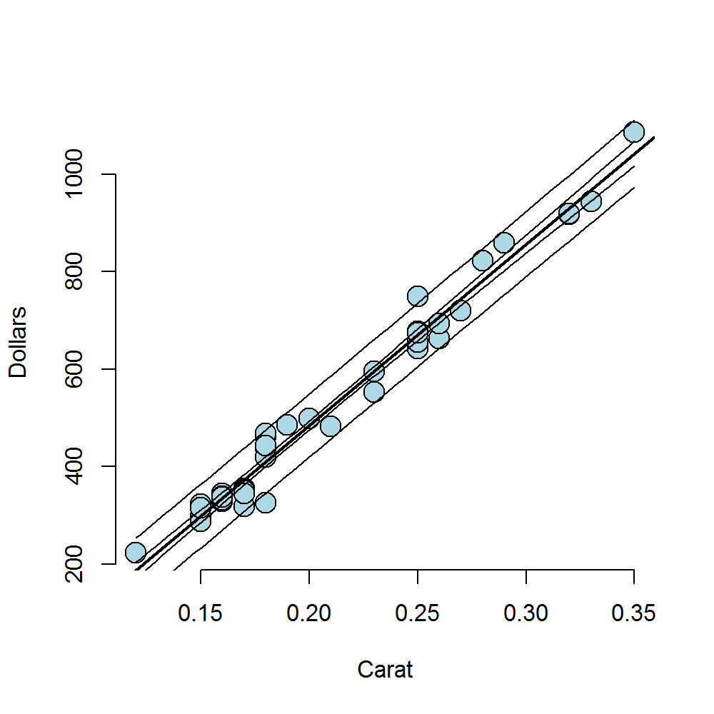